# Lab 03 Preparing Data for Visualization

## RE 519 Data Analytics and Visualization | Autumn 2026

- Lab 03-A: Tidy Data
  - Data Preparation
  - Data Tidying
  - Missing Values
- Lab 03-B: Exploratory Data Analysis in R
  - Skim Datasets
  - First use of `ggplot2`
  - Distribution of Univariate Variable
  - Relationship Between Multivariate Variables
  - 📚 TODO: Review Diagrams
  - 📚 TODO: Explore National Mortgage Database
- Acknowledgement

In lab 3, we are going to explore tidy data, start to visualize data using R, and look at GitHub. The primary dataset we are using is [Zillow Home Value Index (ZHVI)](https://www.zillow.com/research/data/), a measure of the typical home value and market changes across a given region and housing type. More information about what ZHVI is and how it’s calculated is available on [this overview page](https://www.zillow.com/research/methodology-neural-zhvi-32128/).

The submission should include Rmd, html, and any other files required to rerun the codes. **For Lab 1–3, the use of any generative AI tool (ChatGPT, Copilot, etc.) is prohibited**. We will run AI detection on each submission.

> **Recommended Reading**  
> [Chapter 2, 6, Modern Data Science with R. Baumer et al. 2024.](https://mdsr-book.github.io/mdsr3e)  
> [Tidy Data, *The Journal of Statistical Software*, Hadley Wickham, 2014.](https://vita.had.co.nz/papers/tidy-data.html)

## Lab 03-A: Tidy Data

```r
library('tidyverse')
library('ggplot2') # the major package for visualization in R
```

### Data Preparation

Instead of using API or R data package as we did in Lab 1 and 2, we will use data on our local device. We have organized the [Zillow Home Value Index (ZHVI)](https://www.zillow.com/research/data/) for the largest 30 [Metropolitan Statistical Ares (MSA)](https://en.wikipedia.org/wiki/Metropolitan_statistical_area) and their 2024 population in csv file `zillow_hvi_msa.csv`. [Comma-separated values (CSV)](https://en.wikipedia.org/wiki/Comma-separated_values) is a text data format that uses commas to separate delimiter-separated values, and newlines to separate records.

```r
hvi <- read_csv("zillow_hvi_msa.csv")
```

`CSV` files are just plain text. You can use your text editor (TextEdit on Mac and Notepad on Windows) to have a look. They do not store metadata such as column types, units, or formats. So. when we use `read_csv()`, it automatically guesses column types by inspecting the data. Sometimes its guess is wrong, we need to specify the types using `spec()`.

```r
hvi <- read_csv("zillow_hvi_msa.csv",
  col_types = cols(
    RegionName = col_character(),
    StateName  = col_character(),
    Region   = col_character(), # Census Bureau Regions
    RegionID   = col_double(),
    Popu2024   = col_number(),
    .default   = col_double()   # for other columns
  )
)
head(hvi, 2)
```

```
## # A tibble: 2 × 313
##   RegionID RegionName    Popu2024 StateName Region `1/31/00` `2/29/00` `3/31/00`
##      <dbl> <chr>            <dbl> <chr>     <chr>      <dbl>     <dbl>     <dbl>
## 1   394913 New York, NY  19940274 NY        North…   220835.   221773.   222720.
## 2   753899 Los Angeles,… 12927614 CA        West     222016.   222842.   223942.
## # ℹ 305 more variables: `4/30/00` <dbl>, `5/31/00` <dbl>, `6/30/00` <dbl>,
## #   `7/31/00` <dbl>, `8/31/00` <dbl>, `9/30/00` <dbl>, `10/31/00` <dbl>,
## #   `11/30/00` <dbl>, `12/31/00` <dbl>, `1/31/01` <dbl>, `2/28/01` <dbl>,
## #   `3/31/01` <dbl>, `4/30/01` <dbl>, `5/31/01` <dbl>, `6/30/01` <dbl>,
## #   `7/31/01` <dbl>, `8/31/01` <dbl>, `9/30/01` <dbl>, `10/31/01` <dbl>,
## #   `11/30/01` <dbl>, `12/31/01` <dbl>, `1/31/02` <dbl>, `2/28/02` <dbl>,
## #   `3/31/02` <dbl>, `4/30/02` <dbl>, `5/31/02` <dbl>, `6/30/02` <dbl>, …
```

### Data Tidying

**This section was adopted from [Tidy data page](https://cran.r-project.org/web/packages/tidyr/vignettes/tidy-data.html), authored by [Hadley Wickham](https://hadley.nz), I believe.**

> Happy families are all alike; every unhappy family is unhappy in its own way — Leo Tolstoy

Like families, tidy datasets are all alike but every messy dataset is messy in its own way. The principles of tidy data provide a standard way to organize data values within a dataset. A standard makes initial data cleaning easier because you don’t need to start from scratch and reinvent the wheel every time. The tidy data standard has been designed to facilitate initial exploration and analysis of the data, and to simplify the development of data analysis tools that work well together.

#### Data Semantics

A dataset is a collection of **values**, usually either numbers or strings. Values are organised in two ways: every value belongs to a variable and an observation.

- A **variable** contains all values that measure the same underlying attribute (like height, temperature, duration) across units.
- An **observation** contains all values measured on the same unit (like a person, or a day, or a race) across attributes.

```r
head(hvi, 2)
```

```
## # A tibble: 2 × 313
##   RegionID RegionName    Popu2024 StateName Region `1/31/00` `2/29/00` `3/31/00`
##      <dbl> <chr>            <dbl> <chr>     <chr>      <dbl>     <dbl>     <dbl>
## 1   394913 New York, NY  19940274 NY        North…   220835.   221773.   222720.
## 2   753899 Los Angeles,… 12927614 CA        West     222016.   222842.   223942.
## # ℹ 305 more variables: `4/30/00` <dbl>, `5/31/00` <dbl>, `6/30/00` <dbl>,
## #   `7/31/00` <dbl>, `8/31/00` <dbl>, `9/30/00` <dbl>, `10/31/00` <dbl>,
## #   `11/30/00` <dbl>, `12/31/00` <dbl>, `1/31/01` <dbl>, `2/28/01` <dbl>,
## #   `3/31/01` <dbl>, `4/30/01` <dbl>, `5/31/01` <dbl>, `6/30/01` <dbl>,
## #   `7/31/01` <dbl>, `8/31/01` <dbl>, `9/30/01` <dbl>, `10/31/01` <dbl>,
## #   `11/30/01` <dbl>, `12/31/01` <dbl>, `1/31/02` <dbl>, `2/28/02` <dbl>,
## #   `3/31/02` <dbl>, `4/30/02` <dbl>, `5/31/02` <dbl>, `6/30/02` <dbl>, …
```

- `RegionID`: a unique regional ID defined by Zillow
- `RegionalName`: the name of 30 MSA
- `Popu2024`: the population of MSA in 2024 based on US Census Bureau
- `StateName`: state name
- 308 columns representing dates: Housing Value Index on that date

A tidy version of the data looks like this:

```r
hvi_tidy <- hvi %>%
  pivot_longer( # using `pivot_longer` to reshape wide → long
    cols = -c("RegionID", "RegionName", "Popu2024", "StateName", "Region"), # keep these 4 as identifier variables (don’t pivot them)
    names_to = "Date",  # old column names (like "1/31/00") become a new column called Date
    values_to = "HVI" # the cell values go into a new column called HVI
    # values_drop_na = TRUE; default as FALSE; if TRUE, will remove rows with missing HVI.
  ) %>%
  mutate(
    Date = as.Date(Date, format = "%m/%d/%y")
  )
head(hvi_tidy, 2)
```

```
## # A tibble: 2 × 7
##   RegionID RegionName   Popu2024 StateName Region    Date           HVI
##      <dbl> <chr>           <dbl> <chr>     <chr>     <date>       <dbl>
## 1   394913 New York, NY 19940274 NY        Northeast 2000-01-31 220835.
## 2   394913 New York, NY 19940274 NY        Northeast 2000-02-29 221773.
```

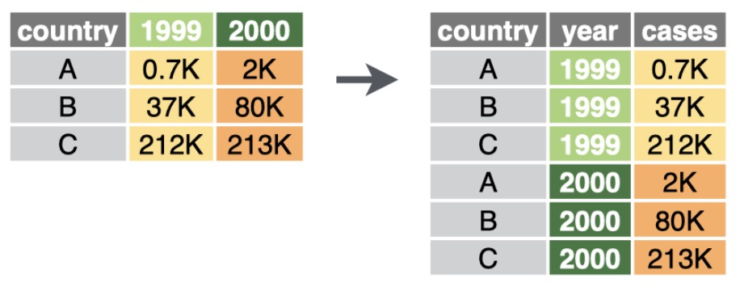

From Wider to Longer. Source: Cheatsheet of tidyr.

- `RegionID`: a unique regional ID defined by Zillow
- `RegionalName`: the name of 30 MSA
- `Popu2024`: the population of MSA in 2024 based on US Census Bureau
- `StateName`: state name
- `Date`: **NEW** - observation date
- `HVI`: **NEW** - Housing Value Index from Zillow

The tidy data frame explicitly tells us the definition of an observation. Every combination of `RegionName` and `Date` is a single measured observation (`HVI`). It’s important to clearly define **what is an observation**. In the case of HVI, we are interested in HVI for sure! For an observation, such as `220834.8`, we need know two information: region and date.

#### Tidy data

In tidy data:

- Each variable is a column; each column is a variable.
- Each observation is a row; each row is an observation.
- Each value is a cell; each cell is a single value.

Tidy data makes it easy for an analyst or a computer to extract needed variables because it provides a standard way of structuring a dataset. Tidy data is particularly well suited for vectorised programming languages like R, because the layout ensures that values of different variables from the same observation are always paired. Many R packages, such as `ggplot2` are designed around the tidy data principles.

#### From Tidy Data to Wider Data

We can use `pivot_wider()` to perform the inverse operation.

```r
hvi_wide <- hvi_tidy %>%
  pivot_wider(
    names_from = Date,   # expand `Date` to multiple rows
    values_from = HVI    # extract`HVI` column to those new columns
  )
head(hvi_wide, 2)
```

```
## # A tibble: 2 × 313
##   RegionID RegionName      Popu2024 StateName Region   `2000-01-31` `2000-02-29`
##      <dbl> <chr>              <dbl> <chr>     <chr>           <dbl>        <dbl>
## 1   394913 New York, NY    19940274 NY        Northea…      220835.      221773.
## 2   753899 Los Angeles, CA 12927614 CA        West          222016.      222842.
## # ℹ 306 more variables: `2000-03-31` <dbl>, `2000-04-30` <dbl>,
## #   `2000-05-31` <dbl>, `2000-06-30` <dbl>, `2000-07-31` <dbl>,
## #   `2000-08-31` <dbl>, `2000-09-30` <dbl>, `2000-10-31` <dbl>,
## #   `2000-11-30` <dbl>, `2000-12-31` <dbl>, `2001-01-31` <dbl>,
## #   `2001-02-28` <dbl>, `2001-03-31` <dbl>, `2001-04-30` <dbl>,
## #   `2001-05-31` <dbl>, `2001-06-30` <dbl>, `2001-07-31` <dbl>,
## #   `2001-08-31` <dbl>, `2001-09-30` <dbl>, `2001-10-31` <dbl>, …
```

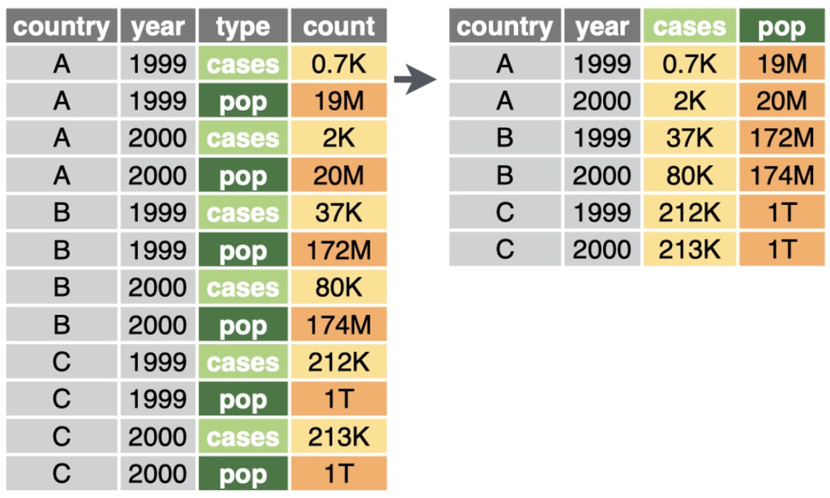

From Longer to Wider. Source: Cheatsheet of tidyr.

### Missing Values

In `pivot_longer`, there is an optional argument called `values_drop_na =`, default as `FALSE`. If setting as `TRUE`, it will remove rows with missing HVI. We set as `FALSE` but is there any `NA` (Not Available) values?

We can use `is.na()` to check and there are 3 missing value in `HVI` column:

```r
colSums(is.na(hvi_tidy))
```

```
##   RegionID RegionName   Popu2024  StateName     Region       Date        HVI
##          0          0          0          0          0          0          3
```

We can remove NA or smooth/impute them based on their neighbors. We will just remove them here because those 3 missing values do not impact too much on our visualization. But, there are many ways you can do data interpolation. It can based on known temporal neighbors, spatial neighbors, group-based neighbors. It goes beyond this course but it’s an important problem for data science. If you are interested in missing data, you can refer to this book: [Statistical Analysis with Missing Data](https://onlinelibrary.wiley.com/doi/book/10.1002/9781119482260).

```r
# remove NA then we can see there are 9237 rows afterwards, 3 missing values are removed
hvi_tidy_NA_remove <- hvi_tidy %>%
  filter(!is.na(HVI))
dim(hvi_tidy_NA_remove)
```

```
## [1] 9237    7
```

#### 📚 TODO: Handle Missing Values

**4 points**

Instead of omitting those missing values, let’s try filling missing values in `hvi_tidy` using a [linear interpolation method](https://en.wikipedia.org/wiki/Linear_interpolation). You can use the `zoo` package, which provides a convenient function `na.approx()` for handling time-series data.

[The documentation](https://www.rdocumentation.org/packages/zoo/versions/1.8-14/topics/na.approx) and [this post](https://www.spsanderson.com/steveondata/posts/2024-11-28/) may be helpful to you!

```r
# TODO
```

## Lab 03-B: Exploratory Data Analysis in R

Starting from this lab session, we are going to conduct data visualization using R and [ggplot2](https://ggplot2.tidyverse.org). You don’t have to install `ggplot2` separately because it is already a part of `tidyverse`.

Exploratory Data Analysis (EDA) is the process of summarizing, visualizing, and checking data to uncover patterns, detect outliers, and identify unexpected features. It helps you understand the structure and quality of your dataset before applying formal statistical models or machine learning methods. The key of EDA is **not** aesthetics, design, or storytelling, but rather developing an understanding of the data itself. However, for learning purposes, we will use ggplot2 because it provides a consistent and flexible framework for visualizing data in R. In realty, you can use any tool, base R plotting, Tableau, Excel, for EDA. What matters is the insight you gain, not the tool itself. This section is partially built based on [Exploratory Data Analysis from EPA](https://www.epa.gov/caddis/exploratory-data-analysis).

### Skim Datasets

The first step of Exploratory Data Analysis (EDA) is to quickly check the structure of the dataset: variable types, missing values, and basic distributions. The `skimr` package provides the `skim()` function, which offers a richer summary than `summary()` we used before.

```r
# install.packages("skimr") # you only need to install once
library(skimr)
skim(hvi_tidy) # run `skim()` to get a quick overview of the dataset
```

Data summary

| Name | hvi_tidy |
| --- | --- |
| Number of rows | 9240 |
| Number of columns | 7 |
| _______________________ |  |
| Column type frequency: |  |
| character | 3 |
| Date | 1 |
| numeric | 3 |
| ________________________ |  |
| Group variables | None |

**Variable type: character**

| skim_variable | n_missing | complete_rate | min | max | empty | n_unique | whitespace |
| --- | --- | --- | --- | --- | --- | --- | --- |
| RegionName | 0 | 1 | 9 | 17 | 0 | 30 | 0 |
| StateName | 0 | 1 | 2 | 2 | 0 | 20 | 0 |
| Region | 0 | 1 | 4 | 9 | 0 | 4 | 0 |

**Variable type: Date**

| skim_variable | n_missing | complete_rate | min | max | median | n_unique |
| --- | --- | --- | --- | --- | --- | --- |
| Date | 0 | 1 | 2000-01-31 | 2025-08-31 | 2012-11-15 | 308 |

**Variable type: numeric**

| skim_variable | n_missing | complete_rate | mean | sd | p0 | p25 | p50 | p75 | p100 | hist |
| --- | --- | --- | --- | --- | --- | --- | --- | --- | --- | --- |
| RegionID | 0 | 1 | 406769.8 | 64464.35 | 394347.0 | 394514.0 | 394928.0 | 395055.0 | 753899 | ▇▁▁▁▁ |
| Popu2024 | 0 | 1 | 5155963.1 | 3678886.70 | 2302815.0 | 2811927.0 | 3951723.0 | 6411149.0 | 19940274 | ▇▂▁▁▁ |
| HVI | 3 | 1 | 295179.8 | 169970.78 | 81356.6 | 170949.5 | 244037.9 | 376662.7 | 1232658 | ▇▃▁▁▁ |

Note: `complete_rate` is the proportion of non-missing values in that variable. In the HTML, we find it is 1 for `HVI` but it’s not the case. This happens because the value is very close to 1 (e.g., 0.9996) and is rounded up.

### First use of `ggplot2`

`ggplot2` is built on the **G**rammar of **G**raphics — a system that describes plots as combinations of independent components. This is a typical chunk of ggplot2.

```
ggplot(data, aes(x = ..., y = ...)) +
  geom_*() +
  facet_*() +
  scale_*() +
  coord_*() +
  theme()
```

Let’s use the ZHVI of Seattle and Portland to complete `ggplot2` figure step by step to understand how each component contributes. We defined one objects with ZHVI of both Seattle and Portland (`hvi_pnw`).

```r
hvi_pnw <- hvi_tidy_NA_remove %>%
  filter(RegionName %in% c("Seattle, WA", "Portland, OR"))
```

Starting from `ggplot()`, we create a plot object. We can define the `data` and and `aes` (or later). We have argument `aes()`, which defines how data fields (e.g., categorical, ordinal) **map to** visual properties (e.g., x, y, color, shape, size).

[figure not shown]

Simplified ggplot. Source: Luka Negoita

If we assign this `ggplot()` object to `g`, we can later add anything upon this object using `+`. Otherwise, the plot will show here. `ggplot()` alone initializes a coordinate system and data mapping, so there is nothing on the diagram.

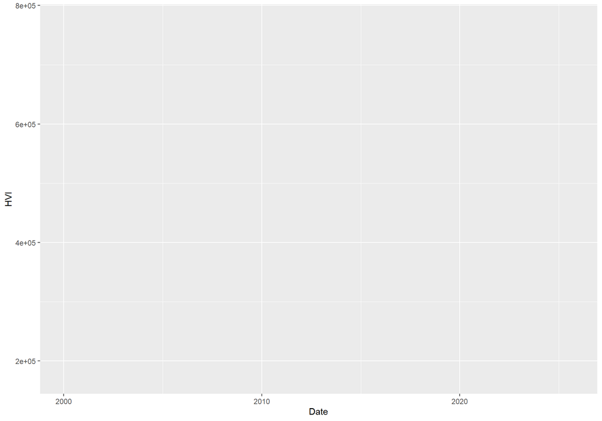

```r
ggplot(hvi_pnw, aes(x = Date, y = HVI, group = RegionName)) # will show below the chunk
```

```r
g <- ggplot(hvi_pnw, aes(x = Date, y = HVI, color = RegionName)) # will not show the plots
```

In `ggplot2`, defining `geom_*()` (geometric object) is required. What do we want in this plot? Points or lines? We can stack more than one `geom_*()` in a plot and each `geom_*()` function will return a layer.

Within `geom_*()` functions, we can modify the visual attributes of this layer. Note: different geometric objects have different arguments.

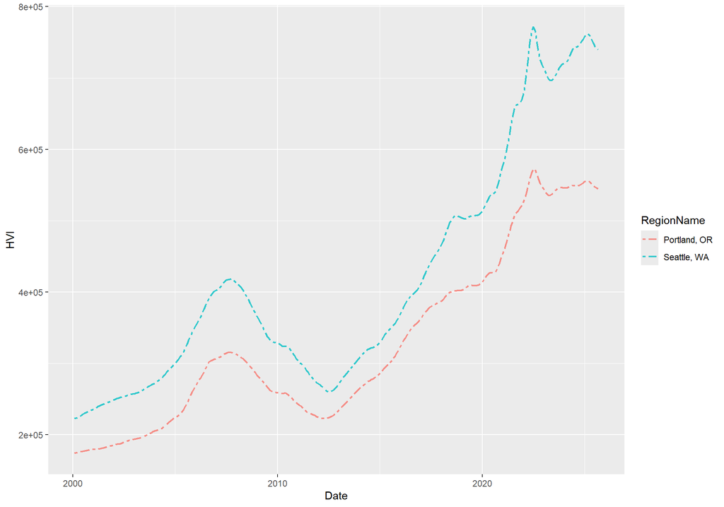

```r
g <- g + geom_line(aes(color = RegionName),
              alpha = 0.8, # Opacity: 0 means fully transparent (invisible)
              linetype = 6, # 6 = twodash, you can check more option using `?linetype`
              linewidth = 0.8) # linewidth
g
```

This is a confusing thing here: we added `aes(color = RegionName)` within `geom_line()`. Why did we use `RegionName` twice, one in `ggplot()` one in `geom_line()`?